# Aerofit Case Study

```python
import numpy as np
import pandas as pd
import seaborn as sns
from scipy.stats import norm
import matplotlib.pyplot as plt
from statsmodels.distributions.empirical_distribution import ECDF
```

## 1. Initial Exploration

### 1.1 Problem Statement

The market research team at AeroFit wants to identify the characteristics of the target audience for each type of treadmill offered by the company, to provide a better recommendation of the treadmills to the new customers. The team decides to investigate whether there are differences across the product with respect to customer characteristics.

### 1.2 Basic Analysis

```python
df = pd.read_csv("aerofit_treadmill.csv")
df.head()
```

|  | Product | Age | Gender | Education | MaritalStatus | Usage | Fitness | Income | Miles |
| --- | --- | --- | --- | --- | --- | --- | --- | --- | --- |
| 0 | KP281 | 18 | Male | 14 | Single | 3 | 4 | 29562 | 112 |
| 1 | KP281 | 19 | Male | 15 | Single | 2 | 3 | 31836 | 75 |
| 2 | KP281 | 19 | Female | 14 | Partnered | 4 | 3 | 30699 | 66 |
| 3 | KP281 | 19 | Male | 12 | Single | 3 | 3 | 32973 | 85 |
| 4 | KP281 | 20 | Male | 13 | Partnered | 4 | 2 | 35247 | 47 |

```python
print(f"Shape of data {df.shape}")
```

```
Shape of data (180, 9)
```

180 rows and 9 Columns

```python
df.info()
```

```
<class 'pandas.core.frame.DataFrame'>
RangeIndex: 180 entries, 0 to 179
Data columns (total 9 columns):
 #   Column         Non-Null Count  Dtype
---  ------         --------------  -----
 0   Product        180 non-null    object
 1   Age            180 non-null    int64
 2   Gender         180 non-null    object
 3   Education      180 non-null    int64
 4   MaritalStatus  180 non-null    object
 5   Usage          180 non-null    int64
 6   Fitness        180 non-null    int64
 7   Income         180 non-null    int64
 8   Miles          180 non-null    int64
dtypes: int64(6), object(3)
memory usage: 12.8+ KB
```

- No null values observed
- 6 Numerical Columns
- 3 Categorical Columns

```python
print(f"Null Values: {df.isna().sum().sum()}")
```

```
Null Values: 0
```

### 1.3 Data Type Conversion

#### Discrete Data Type to Categorical

```python
df["Education"] = df["Education"].astype("object")
df["Usage"] = df["Usage"].astype("object")
df["Fitness"] = df["Fitness"].astype("object")
```

```python
df.info()
```

```
<class 'pandas.core.frame.DataFrame'>
RangeIndex: 180 entries, 0 to 179
Data columns (total 9 columns):
 #   Column         Non-Null Count  Dtype
---  ------         --------------  -----
 0   Product        180 non-null    object
 1   Age            180 non-null    int64
 2   Gender         180 non-null    object
 3   Education      180 non-null    object
 4   MaritalStatus  180 non-null    object
 5   Usage          180 non-null    object
 6   Fitness        180 non-null    object
 7   Income         180 non-null    int64
 8   Miles          180 non-null    int64
dtypes: int64(3), object(6)
memory usage: 12.8+ KB
```

#### Income in 1000's(K)

```python
df["Income"] = round(df["Income"]/1000,2)
```

### 1.4 Statistical Analysis

```python
numerical_analysis = df.describe(percentiles=[0.1,0.2,0.3,0.4,0.5,0.6,0.7,0.8,0.9]).T
numerical_analysis
```

|  | count | mean | std | min | 10% | 20% | 30% | 40% | 50% | 60% | 70% | 80% | 90% | max |
| --- | --- | --- | --- | --- | --- | --- | --- | --- | --- | --- | --- | --- | --- | --- |
| Age | 180.0 | 28.788889 | 6.943498 | 18.00 | 22.00 | 23.00 | 24.70 | 25.00 | 26.000 | 29.000 | 31.300 | 34.2 | 38.10 | 50.00 |
| Income | 180.0 | 53.720000 | 16.507097 | 29.56 | 35.25 | 40.93 | 45.48 | 47.75 | 50.595 | 52.756 | 55.059 | 61.4 | 83.42 | 104.58 |
| Miles | 180.0 | 103.194444 | 51.863605 | 21.00 | 53.00 | 65.60 | 75.00 | 85.00 | 94.000 | 100.000 | 107.800 | 132.0 | 180.00 | 360.00 |

- Average Age is 29 yrs old
- Average I ncome is 53K
- Average miles expected to covered is 103

```python
categorical_analysis = df.describe(include="object").T
categorical_analysis
```

|  | count | unique | top | freq |
| --- | --- | --- | --- | --- |
| Product | 180 | 3 | KP281 | 80 |
| Gender | 180 | 2 | Male | 104 |
| Education | 180 | 8 | 16 | 85 |
| MaritalStatus | 180 | 2 | Partnered | 107 |
| Usage | 180 | 6 | 3 | 69 |
| Fitness | 180 | 5 | 3 | 97 |

#### 1.4.1 Interquartile Range

```python
def iqr(x):
    q3 = x.quantile(0.75)
    q1 = x.quantile(0.25)
    iqr = round(q3-q1,2)
    print(f"Interquartile Range: {iqr}")
    lower = round(max(q1 - 1.5 * iqr, 0),2)
    upper = round(q3 + 1.5 * iqr,2)
    print(f"Range from ({lower},{upper})")
```

```python
df["Income"].max() - df["Income"].min()
```

```
75.02
```

```python
for col in df.columns[df.dtypes != "object"]:
    print(col,":-")
    print("-"*30)
    iqr(df[col])
    print(f"Min Value {df[col].min()}, Max Value {df[col].max()}")
    print("="*30,end="\n\n")
```

```
Age :-
------------------------------
Interquartile Range: 9.0
Range from (10.5,46.5)
Min Value 18, Max Value 50
==============================

Income :-
------------------------------
Interquartile Range: 14.61
Range from (22.14,80.59)
Min Value 29.56, Max Value 104.58
==============================

Miles :-
------------------------------
Interquartile Range: 48.75
Range from (0,187.88)
Min Value 21, Max Value 360
==============================
```

- Major Outliers observed in Miles & Income
- Spread of Miles is quite high
- Spread of age is low

### 1.5 Unique Values & Value Counts

##### Product

```python
print(f'Total Unique values: {df["Product"].nunique()}')
df["Product"].value_counts()
```

```
Total Unique values: 3
```

```
KP281    80
KP481    60
KP781    40
Name: Product, dtype: int64
```

- Most common bough product is KP281

##### Age

```python
print(f'Total Unique values: {df["Age"].nunique()}')
```

```
Total Unique values: 32
```

##### Gender

```python
print(f'Total Unique values: {df["Gender"].nunique()}')
df["Gender"].value_counts()
```

```
Total Unique values: 2
```

```
Male      104
Female     76
Name: Gender, dtype: int64
```

- Male predominately buys treadmill

##### Education

```python
print(f'Total Unique values: {df["Education"].nunique()}')
df["Education"].value_counts()
```

```
Total Unique values: 8
```

```
16    85
14    55
18    23
15     5
13     5
12     3
21     3
20     1
Name: Education, dtype: int64
```

- 16 years most common education

##### Marital Status

```python
print(f'Total Unique values: {df["MaritalStatus"].nunique()}')
df["MaritalStatus"].value_counts()
```

```
Total Unique values: 2
```

```
Partnered    107
Single        73
Name: MaritalStatus, dtype: int64
```

- Couples are more likely to buy treadmill

##### Usage

```python
print(f'Total Unique values: {df["Usage"].nunique()}')
df["Usage"].value_counts()
```

```
Total Unique values: 6
```

```
3    69
4    52
2    33
5    17
6     7
7     2
Name: Usage, dtype: int64
```

- The majority of customers expected usage to be 3

##### Fitness

```python
print(f'Total Unique values: {df["Fitness"].nunique()}')
df["Fitness"].value_counts()
```

```
Total Unique values: 5
```

```
3    97
5    31
2    26
4    24
1     2
Name: Fitness, dtype: int64
```

- The majority of customers consider themselves to be of average fitness level.

##### Income

```python
print(f'Total Unique values: {df["Income"].nunique()}')
```

```
Total Unique values: 61
```

##### Miles

```python
print(f'Total Unique values: {df["Miles"].nunique()}')
```

```
Total Unique values: 37
```

## 2. Visual Analysis

### 2.1 Univariate Analysis

#### 2.1.1 Categorical Analysis

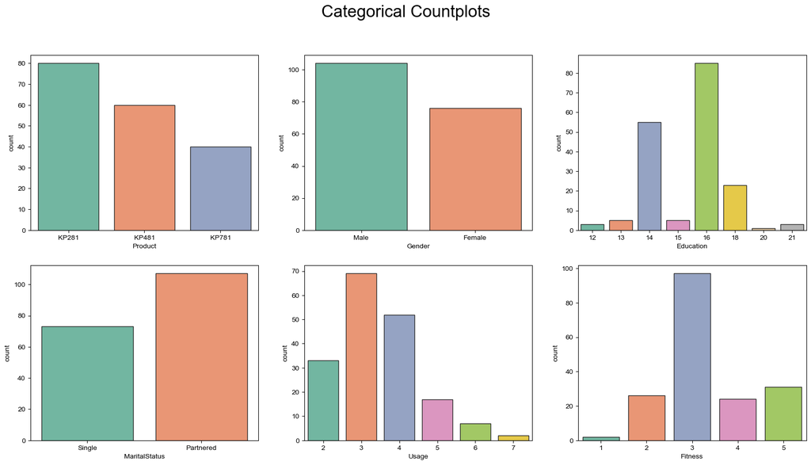

```python
fig, ax = plt.subplots(2,3,figsize=(20,10))
plt.suptitle("Categorical Countplots",fontsize=24)

sns.set_palette(palette="Set2",n_colors=8)
sns.set_style(style="whitegrid")

sns.countplot(x = df["Product"],edgecolor = "0.15",ax=ax[0,0])
sns.countplot(x = df["Gender"],edgecolor = "0.15",ax=ax[0,1])
sns.countplot(x = df["Education"],edgecolor = "0.15",ax=ax[0,2])
sns.countplot(x = df["MaritalStatus"],edgecolor = "0.15",ax=ax[1,0])
sns.countplot(x = df["Usage"],edgecolor = "0.15",ax=ax[1,1])
sns.countplot(x = df["Fitness"],edgecolor = "0.15",ax=ax[1,2])

plt.show()
```

- KP281 is the most commonly ordered treadmill.
- Males account for the majority of the orders.
- The most common years of education among customers are 16, followed by 14.
- The majority of customers are married or have a partner.
- The usage of the treadmills is generally low.
- Most customers consider their fitness level to be average.

#### 2.1.2 Continuous Columns

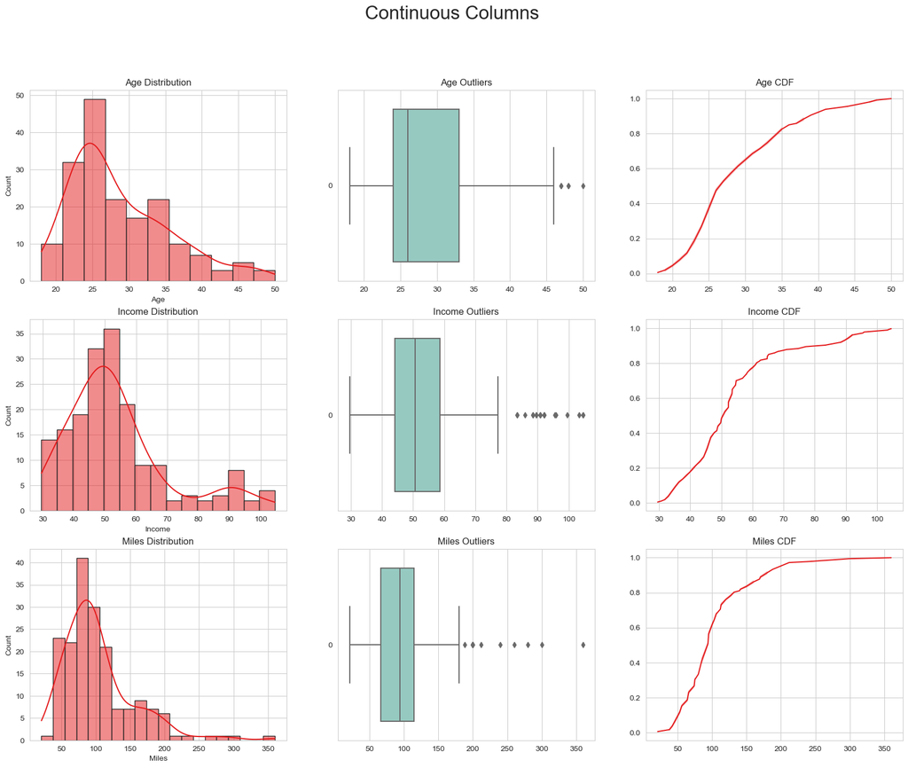

```python
fig,ax = plt.subplots(3,3,figsize=(20,15))
plt.suptitle("Continuous Columns",fontsize=24)

sns.set_palette(palette="Set3",n_colors=8)
sns.set_style(style="whitegrid")

ax[0,0].set_title("Age Distribution")
sns.histplot(df["Age"],kde="True",edgecolor = "0.15", ax=ax[0,0])

ax[0,1].set_title("Age Outliers")
sns.axes_style(style="white")
sns.boxplot(df["Age"],orient='h', ax=ax[0,1])

ax[0,2].set_title("Age CDF")
e = ECDF(df["Age"])
sns.axes_style(style="whitegrid")
sns.lineplot(x = e.x, y = e.y,ax=ax[0,2])

ax[1,0].set_title("Income Distribution")
sns.histplot(df["Income"],kde="True",edgecolor = "0.15", ax=ax[1,0])

ax[1,1].set_title("Income Outliers")
sns.boxplot(df["Income"],orient='h', ax=ax[1,1])

ax[1,2].set_title("Income CDF")
e = ECDF(df["Income"])
sns.lineplot(x = e.x, y = e.y,ax=ax[1,2])

ax[2,0].set_title("Miles Distribution")
sns.histplot(df["Miles"],kde="True",edgecolor = "0.15", ax=ax[2,0])

ax[2,1].set_title("Miles Outliers")
sns.boxplot(df["Miles"],orient='h', ax=ax[2,1])

ax[2,2].set_title("Miles CDF")
e = ECDF(df["Miles"])
sns.lineplot(x = e.x, y = e.y,ax=ax[2,2])

plt.show()
```

### 2.2 Bivariate Analysis

#### 2.2.1 Categorical Columns

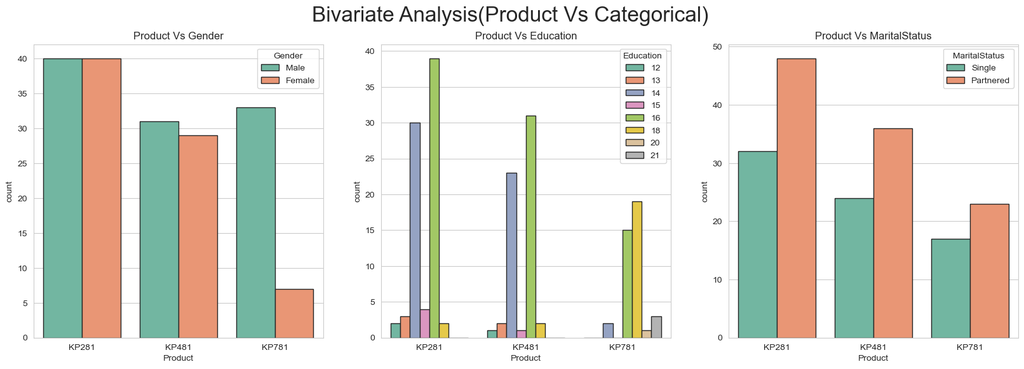

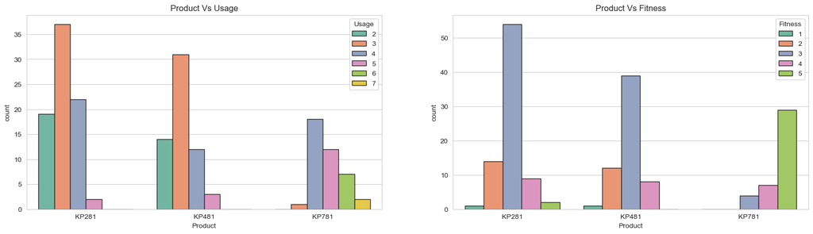

```python
fig,ax = plt.subplots(1,3,figsize=(20,6))
plt.suptitle("Bivariate Analysis(Product Vs Categorical)",fontsize=24)

sns.set_palette(palette="Set2",n_colors=8)
sns.set_style(style="whitegrid")

cols = df.columns[(df.columns!="Product") & (df.dtypes == "object") ].to_list()
for i in range(1):
    for j in range(3):
        ax[j].set_title("Product Vs " + cols[0])
        if df[cols[0]].dtype == int:
            sns.boxplot(data=df, x = "Product", y = cols[0], ax=ax[j])
        else:
            sns.countplot(data=df, x = "Product", hue = cols[0], edgecolor = "0.15", ax=ax[j])
        cols.pop(0)

fig,ax = plt.subplots(1,2,figsize=(20,5))
sns.set_palette(palette="Set2",n_colors=8)
sns.set_style(style="whitegrid")

for i in range(1):
    for j in range(2):
        ax[j].set_title("Product Vs " + cols[0])
        if df[cols[0]].dtype == int:
            sns.boxplot(data=df, x = "Product", y = cols[0], ax=ax[j])
        else:
            sns.countplot(data=df, x = "Product", hue = cols[0], edgecolor = "0.15", ax=ax[j])
        cols.pop(0)
plt.show()
```

- Male customers show a higher preference for ordering KP481 and KP781 treadmills.
- Customers have higher expected usage for KP781 compared to other treadmill models.
- Customers who purchase KP781 tend to consider themselves more fit than others.

#### 2.2.2 Continuous Columns

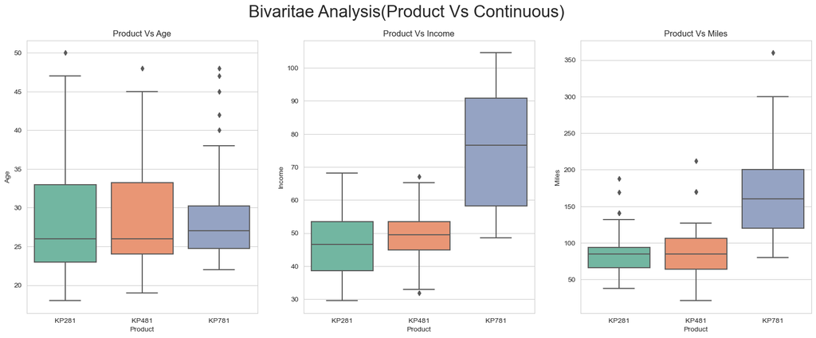

```python
fig,ax = plt.subplots(1,3,figsize=(20,7))
plt.suptitle("Bivaritae Analysis(Product Vs Continuous)",fontsize=24)

sns.set_palette(palette="Set2",n_colors=8)
sns.set_style(style="whitegrid")

cols = df.columns[(df.columns!="Product") & (df.dtypes != "object") ].to_list()
for i in range(1):
    for j in range(3):
        ax[j].set_title("Product Vs " + cols[0])
        if df[cols[0]].dtype != "object":
            sns.boxplot(data=df, x = "Product", y = cols[0], ax=ax[j])
        else:
            sns.countplot(data=df, x = "Product", hue = cols[0], edgecolor = "0.15", ax=ax[j])
        cols.pop(0)
plt.show()
```

- KP781 treadmills are predominantly purchased by the adult audience.
- Customers with a higher income bracket are more likely to buy KP781.
- Individuals who purchase KP781 tend to have a higher inclination to run more compared to others.

### 2.3 Multivariate Analysis

##### Continuous Vs Continuous Vs Categorical

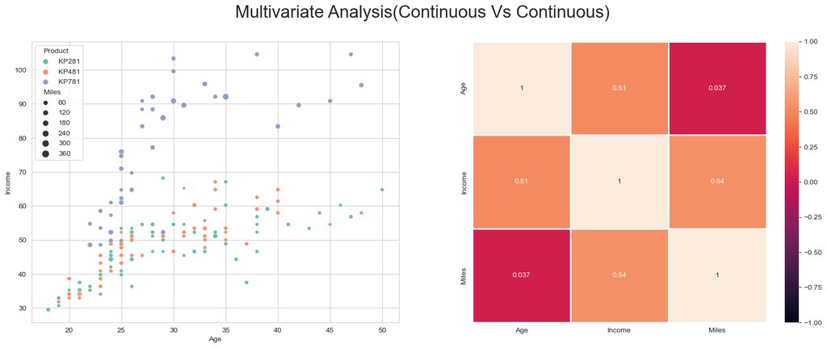

```python
fig,ax = plt.subplots(1,2,figsize=(20,7))
plt.suptitle("Multivariate Analysis(Continuous Vs Continuous)",fontsize=24)

sns.set_palette(palette="Set2",n_colors=8)
sns.set_style(style="whitegrid")

df_corr = df.copy()

sns.scatterplot(data=df,x="Age",y="Income",size="Miles",hue="Product",ax=ax[0])
sns.heatmap(df_corr.corr(),annot=True,linewidths=1,ax=ax[1],vmin=-1)


plt.show()
```

- There is a mild positive correlation between income and age among the customers.
- KP781 users in the age range of 23-37 tend to cover the highest number of miles on average.

##### Product Gender

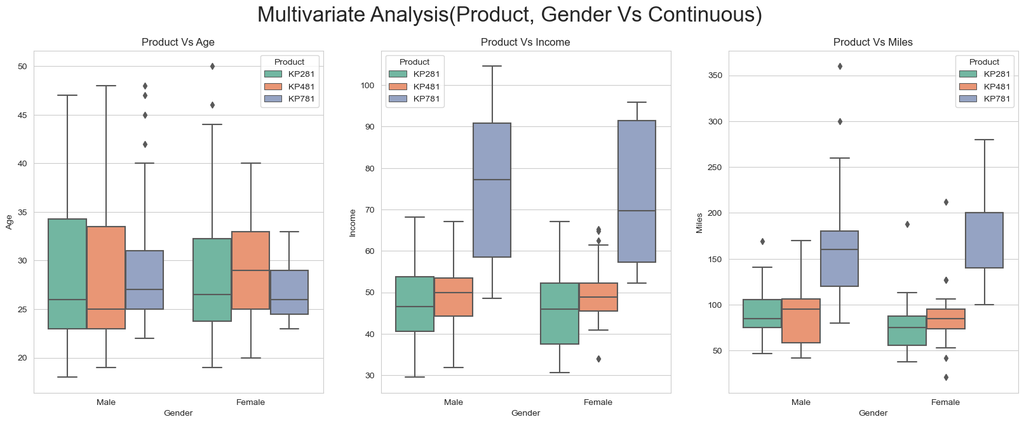

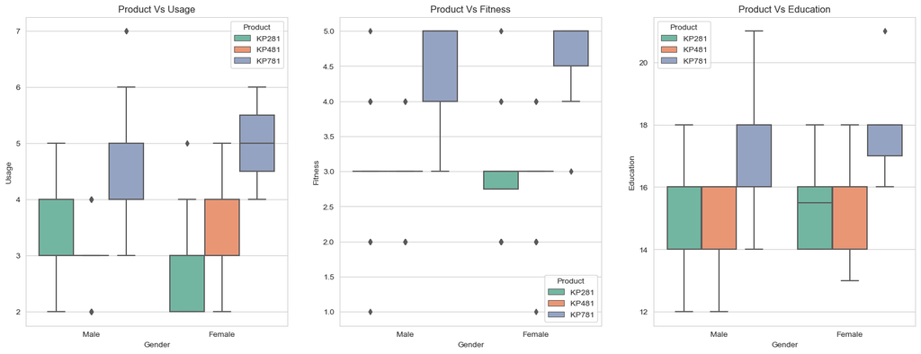

```python
fig,ax = plt.subplots(1,3,figsize=(20,7))
plt.suptitle("Multivariate Analysis(Product, Gender Vs Continuous)",fontsize=24)

sns.set_palette(palette="Set2",n_colors=8)
sns.set_style(style="whitegrid")

cols = df.columns[(df.columns!="Product") & (df.dtypes != "object") ].to_list()
for i in range(1):
    for j in range(3):
        ax[j].set_title("Product Vs " + cols[0])
        sns.boxplot(data=df, x = "Gender", y = cols[0], ax=ax[j],hue="Product")
        cols.pop(0)

fig,ax = plt.subplots(1,3,figsize=(20,7))
cols = ["Usage","Fitness","Education"]
for i in range(1):
    for j in range(3):
        ax[j].set_title("Product Vs " + cols[0])
        sns.boxplot(data=df, x = "Gender", y = cols[0], ax=ax[j],hue="Product")
        cols.pop(0)

plt.show()
```

##### Product Marital Status

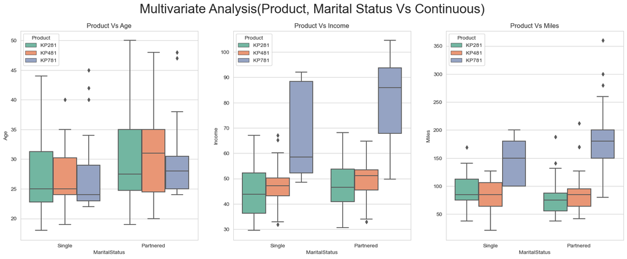

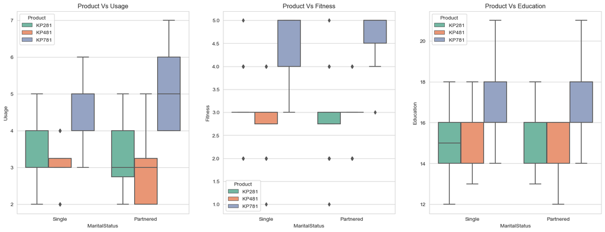

```python
fig,ax = plt.subplots(1,3,figsize=(20,7))
plt.suptitle("Multivariate Analysis(Product, Marital Status Vs Continuous)",fontsize=24)

sns.set_palette(palette="Set2",n_colors=8)
sns.set_style(style="whitegrid")

cols = df.columns[(df.columns!="Product") & (df.dtypes != "object") ].to_list()
for i in range(1):
    for j in range(3):
        ax[j].set_title("Product Vs " + cols[0])
        sns.boxplot(data=df, x = "MaritalStatus", y = cols[0], ax=ax[j],hue="Product")
        cols.pop(0)

fig,ax = plt.subplots(1,3,figsize=(20,7))
cols = ["Usage","Fitness","Education"]
for i in range(1):
    for j in range(3):
        ax[j].set_title("Product Vs " + cols[0])
        sns.boxplot(data=df, x = "MaritalStatus", y = cols[0], ax=ax[j],hue="Product")
        cols.pop(0)

plt.show()
```

##### Pairplot

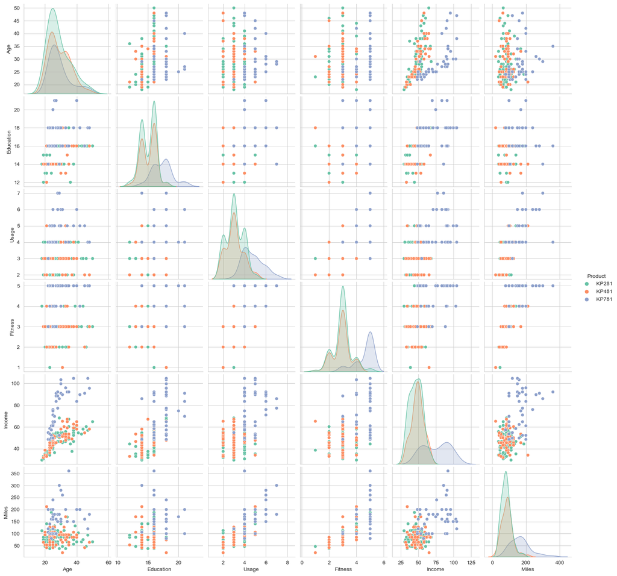

```python
sns.set_palette(palette="Set2",n_colors=8)
sns.set_style(style="whitegrid")
sns.pairplot(data=df,hue="Product")
plt.show()
```

## 3. Probability

##### Binning based on IQR Range

[output not shown]

```python
bins = np.arange(0,70,10)
labels = ['<10','10-20','20-30','30-40','40-50','50+']
df['AgeBin'] = pd.cut(df['Age'], bins=bins, labels=labels)

bins = np.arange(0,140,20)
labels = ['<20','20-40','40-60','60-80','80-100','100+']
df['IncomeBin'] = pd.cut(df['Income'], bins=bins, labels=labels)

bins = np.arange(0,280,40)
labels = ['<40','40-80','80-120','120-160','160-200','200+']
df['MilesBin'] = pd.cut(df['Miles'], bins=bins, labels=labels)

bins = [0,12,14,16,18,20,22]
labels = ['0-12','12-14','14-16','16-18','18-20','20+']
df['EducationBin'] = pd.cut(df['Education'], bins=bins, labels=labels)

df.head()
```

|  | Product | Age | Gender | Education | MaritalStatus | Usage | Fitness | Income | Miles | AgeBin | IncomeBin | MilesBin | EducationBin |
| --- | --- | --- | --- | --- | --- | --- | --- | --- | --- | --- | --- | --- | --- |
| 0 | KP281 | 18 | Male | 14 | Single | 3 | 4 | 29.56 | 112 | 10-20 | 20-40 | 80-120 | 12-14 |
| 1 | KP281 | 19 | Male | 15 | Single | 2 | 3 | 31.84 | 75 | 10-20 | 20-40 | 40-80 | 14-16 |
| 2 | KP281 | 19 | Female | 14 | Partnered | 4 | 3 | 30.70 | 66 | 10-20 | 20-40 | 40-80 | 12-14 |
| 3 | KP281 | 19 | Male | 12 | Single | 3 | 3 | 32.97 | 85 | 10-20 | 20-40 | 80-120 | 0-12 |
| 4 | KP281 | 20 | Male | 13 | Partnered | 4 | 2 | 35.25 | 47 | 10-20 | 20-40 | 40-80 | 12-14 |

##### Gender

```python
gender_prob = round(pd.crosstab(index=df['Gender'],columns=df['Product'],margins=True, normalize=True),2)
gender_prob
```

| Product Gender | KP281 | KP481 | KP781 | All |
| --- | --- | --- | --- | --- |
| Female | 0.22 | 0.16 | 0.04 | 0.42 |
| Male | 0.22 | 0.17 | 0.18 | 0.58 |
| All | 0.44 | 0.33 | 0.22 | 1.00 |

```python
product_prob_given_gender = pd.crosstab(index=df['Gender'],columns=df['Product'],margins=True).apply(lambda x: x/x.iloc[-1],axis=1).round(2)
product_prob_given_gender
```

| Product Gender | KP281 | KP481 | KP781 | All |
| --- | --- | --- | --- | --- |
| Female | 0.53 | 0.38 | 0.09 | 1.0 |
| Male | 0.38 | 0.30 | 0.32 | 1.0 |
| All | 0.44 | 0.33 | 0.22 | 1.0 |

```python
gender_prob_given_product = pd.crosstab(index=df['Gender'],columns=df['Product'],margins=True).apply(lambda x: x/x.iloc[-1],axis=0).round(2)
gender_prob_given_product
```

| Product Gender | KP281 | KP481 | KP781 | All |
| --- | --- | --- | --- | --- |
| Female | 0.5 | 0.48 | 0.18 | 0.42 |
| Male | 0.5 | 0.52 | 0.82 | 0.58 |
| All | 1.0 | 1.00 | 1.00 | 1.00 |

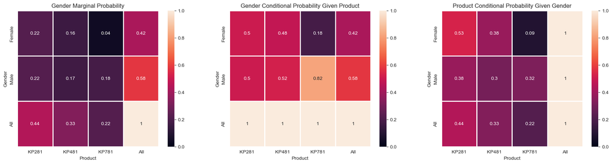

```python
fig,ax = plt.subplots(1,3,figsize=(22,5))

ax[0].set_title("Gender Marginal Probability")
sns.heatmap(gender_prob, linewidth = 1, annot = True,ax= ax[0],vmin=0)

ax[1].set_title("Gender Conditional Probability Given Product")
sns.heatmap(gender_prob_given_product, linewidth = 1, annot = True,ax= ax[1],vmin=0)

ax[2].set_title("Product Conditional Probability Given Gender")
sns.heatmap(product_prob_given_gender, linewidth = 1, annot = True,ax= ax[2],vmin=0)


plt.show()
```

- There is a higher likelihood of males purchasing KP781 treadmills.
- KP281 treadmills are predominantly favored by women.
- Women show less interest in purchasing KP781 treadmills compared to other products.

##### Marital Status

```python
marital_prob = round(pd.crosstab(index=df['MaritalStatus'],columns=df['Product'],margins=True, normalize=True),2)
marital_prob
```

| Product MaritalStatus | KP281 | KP481 | KP781 | All |
| --- | --- | --- | --- | --- |
| Partnered | 0.27 | 0.20 | 0.13 | 0.59 |
| Single | 0.18 | 0.13 | 0.09 | 0.41 |
| All | 0.44 | 0.33 | 0.22 | 1.00 |

```python
product_prob_given_marital = pd.crosstab(index=df['MaritalStatus'],columns=df['Product'],margins=True).apply(lambda x: x/x.iloc[-1],axis=1).round(2)
product_prob_given_marital
```

| Product MaritalStatus | KP281 | KP481 | KP781 | All |
| --- | --- | --- | --- | --- |
| Partnered | 0.45 | 0.34 | 0.21 | 1.0 |
| Single | 0.44 | 0.33 | 0.23 | 1.0 |
| All | 0.44 | 0.33 | 0.22 | 1.0 |

```python
marital_prob_given_product = pd.crosstab(index=df['MaritalStatus'],columns=df['Product'],margins=True).apply(lambda x: x/x.iloc[-1],axis=0).round(2)
marital_prob_given_product
```

| Product MaritalStatus | KP281 | KP481 | KP781 | All |
| --- | --- | --- | --- | --- |
| Partnered | 0.6 | 0.6 | 0.57 | 0.59 |
| Single | 0.4 | 0.4 | 0.42 | 0.41 |
| All | 1.0 | 1.0 | 1.00 | 1.00 |

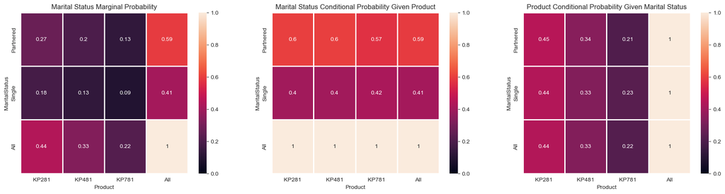

```python
fig,ax = plt.subplots(1,3,figsize=(22,5))

ax[0].set_title("Marital Status Marginal Probability")
sns.heatmap(marital_prob, linewidth = 1, annot = True,ax= ax[0],vmin=0)

ax[1].set_title("Marital Status Conditional Probability Given Product")
sns.heatmap(marital_prob_given_product, linewidth = 1, annot = True,ax= ax[1],vmin=0)

ax[2].set_title("Product Conditional Probability Given Marital Status")
sns.heatmap(product_prob_given_marital, linewidth = 1, annot = True,ax= ax[2],vmin=0)


plt.show()
```

- The target audience for the treadmills is expected to primarily consist of married individuals.

##### Usage

```python
usage_prob = round(pd.crosstab(index=df['Usage'],columns=df['Product'],margins=True, normalize=True),2)
usage_prob
```

| Product Usage | KP281 | KP481 | KP781 | All |
| --- | --- | --- | --- | --- |
| 2 | 0.11 | 0.08 | 0.00 | 0.18 |
| 3 | 0.21 | 0.17 | 0.01 | 0.38 |
| 4 | 0.12 | 0.07 | 0.10 | 0.29 |
| 5 | 0.01 | 0.02 | 0.07 | 0.09 |
| 6 | 0.00 | 0.00 | 0.04 | 0.04 |
| 7 | 0.00 | 0.00 | 0.01 | 0.01 |
| All | 0.44 | 0.33 | 0.22 | 1.00 |

```python
product_prob_given_usage = pd.crosstab(index=df['Usage'],columns=df['Product'],margins=True).apply(lambda x: x/x.iloc[-1],axis=1).round(2)
product_prob_given_usage
```

| Product Usage | KP281 | KP481 | KP781 | All |
| --- | --- | --- | --- | --- |
| 2 | 0.58 | 0.42 | 0.00 | 1.0 |
| 3 | 0.54 | 0.45 | 0.01 | 1.0 |
| 4 | 0.42 | 0.23 | 0.35 | 1.0 |
| 5 | 0.12 | 0.18 | 0.71 | 1.0 |
| 6 | 0.00 | 0.00 | 1.00 | 1.0 |
| 7 | 0.00 | 0.00 | 1.00 | 1.0 |
| All | 0.44 | 0.33 | 0.22 | 1.0 |

```python
usage_prob_given_product = pd.crosstab(index=df['Usage'],columns=df['Product'],margins=True).apply(lambda x: x/x.iloc[-1],axis=0).round(2)
usage_prob_given_product
```

| Product Usage | KP281 | KP481 | KP781 | All |
| --- | --- | --- | --- | --- |
| 2 | 0.24 | 0.23 | 0.00 | 0.18 |
| 3 | 0.46 | 0.52 | 0.02 | 0.38 |
| 4 | 0.28 | 0.20 | 0.45 | 0.29 |
| 5 | 0.02 | 0.05 | 0.30 | 0.09 |
| 6 | 0.00 | 0.00 | 0.18 | 0.04 |
| 7 | 0.00 | 0.00 | 0.05 | 0.01 |
| All | 1.00 | 1.00 | 1.00 | 1.00 |

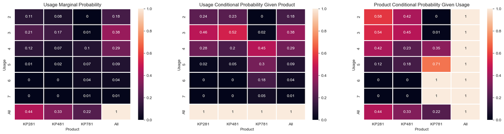

```python
fig,ax = plt.subplots(1,3,figsize=(22,5))

ax[0].set_title("Usage Marginal Probability")
sns.heatmap(usage_prob, linewidth = 1, annot = True,ax= ax[0],vmin=0)

ax[1].set_title("Usage Conditional Probability Given Product")
sns.heatmap(usage_prob_given_product, linewidth = 1, annot = True,ax= ax[1],vmin=0)

ax[2].set_title("Product Conditional Probability Given Usage")
sns.heatmap(product_prob_given_usage, linewidth = 1, annot = True,ax= ax[2],vmin=0)


plt.show()
```

- Customers who rate their treadmill usage as 3 are more inclined to purchase KP281 treadmills.
- Buyers who rate their usage as 5 or above are more likely to opt for KP781 treadmills.

##### Fitness

```python
fitness_prob = round(pd.crosstab(index=df['Fitness'],columns=df['Product'],margins=True, normalize=True),2)
fitness_prob
```

| Product Fitness | KP281 | KP481 | KP781 | All |
| --- | --- | --- | --- | --- |
| 1 | 0.01 | 0.01 | 0.00 | 0.01 |
| 2 | 0.08 | 0.07 | 0.00 | 0.14 |
| 3 | 0.30 | 0.22 | 0.02 | 0.54 |
| 4 | 0.05 | 0.04 | 0.04 | 0.13 |
| 5 | 0.01 | 0.00 | 0.16 | 0.17 |
| All | 0.44 | 0.33 | 0.22 | 1.00 |

```python
product_prob_given_fitness = pd.crosstab(index=df['Fitness'],columns=df['Product'],margins=True).apply(lambda x: x/x.iloc[-1],axis=1).round(2)
product_prob_given_fitness
```

| Product Fitness | KP281 | KP481 | KP781 | All |
| --- | --- | --- | --- | --- |
| 1 | 0.50 | 0.50 | 0.00 | 1.0 |
| 2 | 0.54 | 0.46 | 0.00 | 1.0 |
| 3 | 0.56 | 0.40 | 0.04 | 1.0 |
| 4 | 0.38 | 0.33 | 0.29 | 1.0 |
| 5 | 0.06 | 0.00 | 0.94 | 1.0 |
| All | 0.44 | 0.33 | 0.22 | 1.0 |

```python
fitness_prob_given_product = pd.crosstab(index=df['Fitness'],columns=df['Product'],margins=True).apply(lambda x: x/x.iloc[-1],axis=0).round(2)
fitness_prob_given_product
```

| Product Fitness | KP281 | KP481 | KP781 | All |
| --- | --- | --- | --- | --- |
| 1 | 0.01 | 0.02 | 0.00 | 0.01 |
| 2 | 0.18 | 0.20 | 0.00 | 0.14 |
| 3 | 0.68 | 0.65 | 0.10 | 0.54 |
| 4 | 0.11 | 0.13 | 0.18 | 0.13 |
| 5 | 0.02 | 0.00 | 0.72 | 0.17 |
| All | 1.00 | 1.00 | 1.00 | 1.00 |

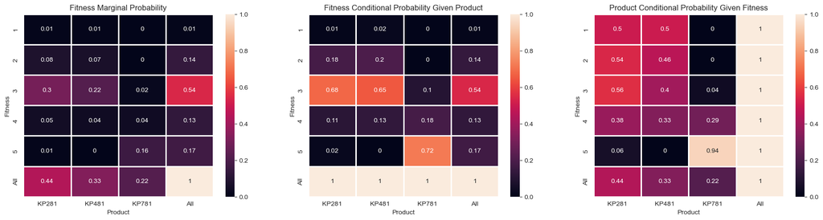

```python
fig,ax = plt.subplots(1,3,figsize=(22,5))

ax[0].set_title("Fitness Marginal Probability")
sns.heatmap(fitness_prob, linewidth = 1, annot = True,ax= ax[0],vmin=0)

ax[1].set_title("Fitness Conditional Probability Given Product")
sns.heatmap(fitness_prob_given_product, linewidth = 1, annot = True,ax= ax[1],vmin=0)

ax[2].set_title("Product Conditional Probability Given Fitness")
sns.heatmap(product_prob_given_fitness, linewidth = 1, annot = True,ax= ax[2],vmin=0)


plt.show()
```

##### Education

```python
education_prob = round(pd.crosstab(index=df['EducationBin'],columns=df['Product'],margins=True, normalize=True),2)
education_prob
```

| Product EducationBin | KP281 | KP481 | KP781 | All |
| --- | --- | --- | --- | --- |
| 0-12 | 0.01 | 0.01 | 0.00 | 0.02 |
| 12-14 | 0.18 | 0.14 | 0.01 | 0.33 |
| 14-16 | 0.24 | 0.18 | 0.08 | 0.50 |
| 16-18 | 0.01 | 0.01 | 0.11 | 0.13 |
| 18-20 | 0.00 | 0.00 | 0.01 | 0.01 |
| 20+ | 0.00 | 0.00 | 0.02 | 0.02 |
| All | 0.44 | 0.33 | 0.22 | 1.00 |

```python
product_prob_given_education = pd.crosstab(index=df['EducationBin'],columns=df['Product'],margins=True).apply(lambda x: x/x.iloc[-1],axis=1).round(2)
product_prob_given_education
```

| Product EducationBin | KP281 | KP481 | KP781 | All |
| --- | --- | --- | --- | --- |
| 0-12 | 0.67 | 0.33 | 0.00 | 1.0 |
| 12-14 | 0.55 | 0.42 | 0.03 | 1.0 |
| 14-16 | 0.48 | 0.36 | 0.17 | 1.0 |
| 16-18 | 0.09 | 0.09 | 0.83 | 1.0 |
| 18-20 | 0.00 | 0.00 | 1.00 | 1.0 |
| 20+ | 0.00 | 0.00 | 1.00 | 1.0 |
| All | 0.44 | 0.33 | 0.22 | 1.0 |

```python
education_prob_given_product = pd.crosstab(index=df['EducationBin'],columns=df['Product'],margins=True).apply(lambda x: x/x.iloc[-1],axis=0).round(2)
education_prob_given_product
```

| Product EducationBin | KP281 | KP481 | KP781 | All |
| --- | --- | --- | --- | --- |
| 0-12 | 0.02 | 0.02 | 0.00 | 0.02 |
| 12-14 | 0.41 | 0.42 | 0.05 | 0.33 |
| 14-16 | 0.54 | 0.53 | 0.38 | 0.50 |
| 16-18 | 0.02 | 0.03 | 0.48 | 0.13 |
| 18-20 | 0.00 | 0.00 | 0.02 | 0.01 |
| 20+ | 0.00 | 0.00 | 0.08 | 0.02 |
| All | 1.00 | 1.00 | 1.00 | 1.00 |

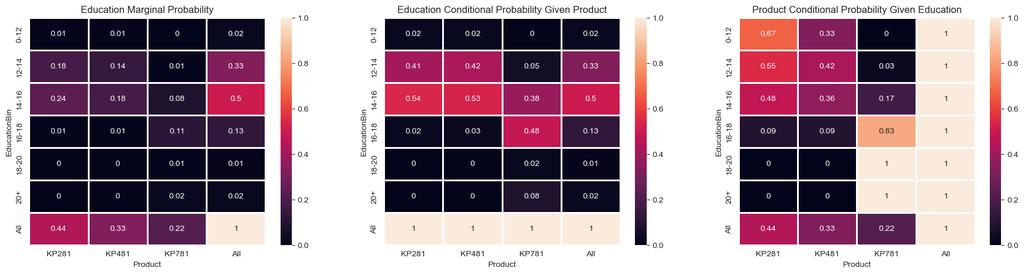

```python
fig,ax = plt.subplots(1,3,figsize=(22,5))

ax[0].set_title("Education Marginal Probability")
sns.heatmap(education_prob, linewidth = 1, annot = True,ax= ax[0],vmin=0)

ax[1].set_title("Education Conditional Probability Given Product")
sns.heatmap(education_prob_given_product, linewidth = 1, annot = True,ax= ax[1],vmin=0)

ax[2].set_title("Product Conditional Probability Given Education")
sns.heatmap(product_prob_given_education, linewidth = 1, annot = True,ax= ax[2],vmin=0)


plt.show()
```

- Individuals with 0-12 years of education are more likely to purchase KP281 treadmills.
- KP781 treadmills are most commonly purchased by customers with 16+ years of education.

##### Age

```python
age_prob = round(pd.crosstab(index=df['AgeBin'],columns=df['Product'],margins=True, normalize=True),2)
age_prob
```

| Product AgeBin | KP281 | KP481 | KP781 | All |
| --- | --- | --- | --- | --- |
| 10-20 | 0.03 | 0.02 | 0.00 | 0.06 |
| 20-30 | 0.27 | 0.17 | 0.17 | 0.61 |
| 30-40 | 0.11 | 0.13 | 0.03 | 0.27 |
| 40-50 | 0.03 | 0.01 | 0.02 | 0.07 |
| All | 0.44 | 0.33 | 0.22 | 1.00 |

```python
product_prob_given_age = pd.crosstab(index=df['AgeBin'],columns=df['Product'],margins=True).apply(lambda x: x/x.iloc[-1],axis=1).round(2)
product_prob_given_age
```

| Product AgeBin | KP281 | KP481 | KP781 | All |
| --- | --- | --- | --- | --- |
| 10-20 | 0.60 | 0.40 | 0.00 | 1.0 |
| 20-30 | 0.45 | 0.28 | 0.27 | 1.0 |
| 30-40 | 0.40 | 0.48 | 0.12 | 1.0 |
| 40-50 | 0.50 | 0.17 | 0.33 | 1.0 |
| All | 0.44 | 0.33 | 0.22 | 1.0 |

```python
age_prob_given_product = pd.crosstab(index=df['AgeBin'],columns=df['Product'],margins=True).apply(lambda x: x/x.iloc[-1],axis=0).round(2)
age_prob_given_product
```

| Product AgeBin | KP281 | KP481 | KP781 | All |
| --- | --- | --- | --- | --- |
| 10-20 | 0.08 | 0.07 | 0.00 | 0.06 |
| 20-30 | 0.61 | 0.52 | 0.75 | 0.61 |
| 30-40 | 0.24 | 0.38 | 0.15 | 0.27 |
| 40-50 | 0.08 | 0.03 | 0.10 | 0.07 |
| All | 1.00 | 1.00 | 1.00 | 1.00 |

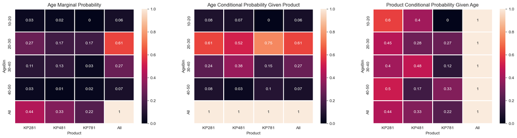

```python
fig,ax = plt.subplots(1,3,figsize=(22,5))

ax[0].set_title("Age Marginal Probability")
sns.heatmap(age_prob, linewidth = 1, annot = True,ax= ax[0],vmin=0)

ax[1].set_title("Age Conditional Probability Given Product")
sns.heatmap(age_prob_given_product, linewidth = 1, annot = True,ax= ax[1],vmin=0)

ax[2].set_title("Product Conditional Probability Given Age")
sns.heatmap(product_prob_given_age, linewidth = 1, annot = True,ax= ax[2],vmin=0)

plt.show()
```

- The age groups of 18-20 and 40-50 are more likely to purchase KP281 treadmills.
- Individuals in the age range of 30-40 years are most likely to be the buyers of KP481 treadmills.

##### Income

```python
income_prob = round(pd.crosstab(index=df['IncomeBin'],columns=df['Product'],margins=True, normalize=True),2)
income_prob
```

| Product IncomeBin | KP281 | KP481 | KP781 | All |
| --- | --- | --- | --- | --- |
| 20-40 | 0.13 | 0.05 | 0.00 | 0.18 |
| 40-60 | 0.28 | 0.24 | 0.06 | 0.59 |
| 60-80 | 0.03 | 0.04 | 0.06 | 0.13 |
| 80-100 | 0.00 | 0.00 | 0.09 | 0.09 |
| 100+ | 0.00 | 0.00 | 0.02 | 0.02 |
| All | 0.44 | 0.33 | 0.22 | 1.00 |

```python
product_prob_given_income = pd.crosstab(index=df['IncomeBin'],columns=df['Product'],margins=True).apply(lambda x: x/x.iloc[-1],axis=1).round(2)
product_prob_given_income
```

| Product IncomeBin | KP281 | KP481 | KP781 | All |
| --- | --- | --- | --- | --- |
| 20-40 | 0.72 | 0.28 | 0.00 | 1.0 |
| 40-60 | 0.48 | 0.42 | 0.10 | 1.0 |
| 60-80 | 0.26 | 0.30 | 0.43 | 1.0 |
| 80-100 | 0.00 | 0.00 | 1.00 | 1.0 |
| 100+ | 0.00 | 0.00 | 1.00 | 1.0 |
| All | 0.44 | 0.33 | 0.22 | 1.0 |

```python
income_prob_given_product = pd.crosstab(index=df['IncomeBin'],columns=df['Product'],margins=True).apply(lambda x: x/x.iloc[-1],axis=0).round(2)
income_prob_given_product
```

| Product IncomeBin | KP281 | KP481 | KP781 | All |
| --- | --- | --- | --- | --- |
| 20-40 | 0.29 | 0.15 | 0.00 | 0.18 |
| 40-60 | 0.64 | 0.73 | 0.28 | 0.59 |
| 60-80 | 0.08 | 0.12 | 0.25 | 0.13 |
| 80-100 | 0.00 | 0.00 | 0.40 | 0.09 |
| 100+ | 0.00 | 0.00 | 0.08 | 0.02 |
| All | 1.00 | 1.00 | 1.00 | 1.00 |

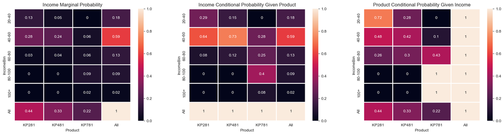

```python
fig,ax = plt.subplots(1,3,figsize=(22,5))

ax[0].set_title("Income Marginal Probability")
sns.heatmap(income_prob, linewidth = 1, annot = True,ax= ax[0],vmin=0)

ax[1].set_title("Income Conditional Probability Given Product")
sns.heatmap(income_prob_given_product, linewidth = 1, annot = True,ax= ax[1],vmin=0)

ax[2].set_title("Product Conditional Probability Given Income")
sns.heatmap(product_prob_given_income, linewidth = 1, annot = True,ax= ax[2],vmin=0)


plt.show()
```

##### Miles

```python
miles_prob = round(pd.crosstab(index=df['MilesBin'],columns=df['Product'],margins=True, normalize=True),2)
miles_prob
```

| Product MilesBin | KP281 | KP481 | KP781 | All |
| --- | --- | --- | --- | --- |
| <40 | 0.02 | 0.01 | 0.00 | 0.02 |
| 40-80 | 0.20 | 0.11 | 0.01 | 0.32 |
| 80-120 | 0.20 | 0.18 | 0.06 | 0.44 |
| 120-160 | 0.02 | 0.03 | 0.06 | 0.11 |
| 160-200 | 0.01 | 0.01 | 0.07 | 0.10 |
| 200+ | 0.00 | 0.01 | 0.01 | 0.01 |
| All | 0.45 | 0.34 | 0.20 | 1.00 |

```python
product_prob_given_miles = pd.crosstab(index=df['MilesBin'],columns=df['Product'],margins=True).apply(lambda x: x/x.iloc[-1],axis=1).round(2)
product_prob_given_miles
```

| Product MilesBin | KP281 | KP481 | KP781 | All |
| --- | --- | --- | --- | --- |
| <40 | 0.75 | 0.25 | 0.00 | 1.0 |
| 40-80 | 0.62 | 0.36 | 0.02 | 1.0 |
| 80-120 | 0.46 | 0.40 | 0.14 | 1.0 |
| 120-160 | 0.21 | 0.26 | 0.53 | 1.0 |
| 160-200 | 0.12 | 0.12 | 0.76 | 1.0 |
| 200+ | 0.00 | 0.50 | 0.50 | 1.0 |
| All | 0.45 | 0.34 | 0.20 | 1.0 |

```python
miles_prob_given_product = pd.crosstab(index=df['MilesBin'],columns=df['Product'],margins=True).apply(lambda x: x/x.iloc[-1],axis=0).round(2)
miles_prob_given_product
```

| Product MilesBin | KP281 | KP481 | KP781 | All |
| --- | --- | --- | --- | --- |
| <40 | 0.04 | 0.02 | 0.00 | 0.02 |
| 40-80 | 0.44 | 0.33 | 0.03 | 0.32 |
| 80-120 | 0.45 | 0.52 | 0.31 | 0.44 |
| 120-160 | 0.05 | 0.08 | 0.28 | 0.11 |
| 160-200 | 0.02 | 0.03 | 0.36 | 0.10 |
| 200+ | 0.00 | 0.02 | 0.03 | 0.01 |
| All | 1.00 | 1.00 | 1.00 | 1.00 |

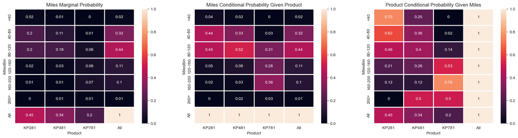

```python
fig,ax = plt.subplots(1,3,figsize=(22,5))

ax[0].set_title("Miles Marginal Probability")
sns.heatmap(miles_prob, linewidth = 1, annot = True,ax= ax[0],vmin=0)

ax[1].set_title("Miles Conditional Probability Given Product")
sns.heatmap(miles_prob_given_product, linewidth = 1, annot = True,ax= ax[1],vmin=0)

ax[2].set_title("Product Conditional Probability Given Miles")
sns.heatmap(product_prob_given_miles, linewidth = 1, annot = True,ax= ax[2],vmin=0)


plt.show()
```

- Customers who run below 40 miles or between 40-80 miles are more likely to buy KP281 treadmills.
- Individuals who run between 120-200 miles are most likely to purchase KP781 treadmills.

##### Gender Education

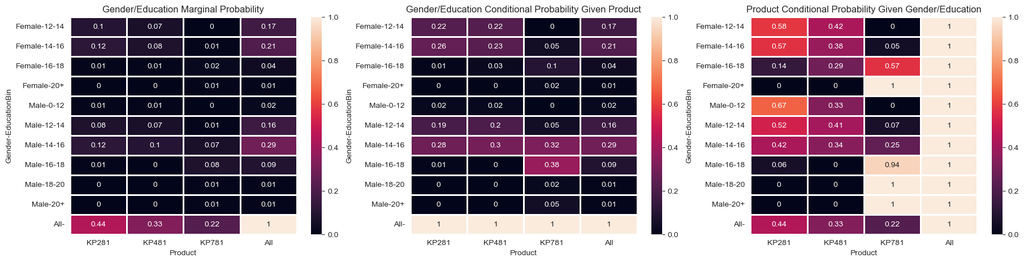

```python
gender_ed_prob = round(pd.crosstab(index=[df["Gender"],df["EducationBin"]],columns=df["Product"],margins=True,normalize=True),2)
product_prob_given_gender_ed = pd.crosstab(index=[df["Gender"],df["EducationBin"]],columns=df['Product'],margins=True).apply(lambda x: x/x.iloc[-1],axis=1).round(2)
gender_ed_prob_given_product = pd.crosstab(index=[df["Gender"],df["EducationBin"]],columns=df['Product'],margins=True).apply(lambda x: x/x.iloc[-1],axis=0).round(2)

fig,ax = plt.subplots(1,3,figsize=(22,5))

ax[0].set_title("Gender/Education Marginal Probability")
sns.heatmap(gender_ed_prob, linewidth = 1, annot = True,ax= ax[0],vmin=0)

ax[1].set_title("Gender/Education Conditional Probability Given Product")
sns.heatmap(gender_ed_prob_given_product, linewidth = 1, annot = True,ax= ax[1],vmin=0)

ax[2].set_title("Product Conditional Probability Given Gender/Education")
sns.heatmap(product_prob_given_gender_ed, linewidth = 1, annot = True,ax= ax[2],vmin=0)


plt.show()
```

- Female buyers with 12-16 years of education are more likely to purchase KP281 treadmills, while females with 20+ years of education show interest in buying KP781.
- Male customers with 0-12 years of education are most likely to purchase KP281, while males above 16 years of education are more inclined to invest in the premium product, KP781.

##### Gender Age

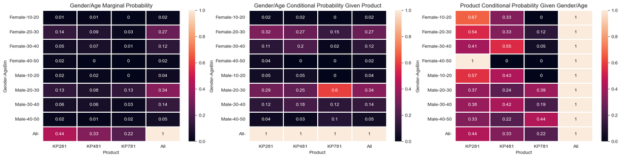

```python
gender_age_prob = round(pd.crosstab(index=[df["Gender"],df["AgeBin"]],columns=df["Product"],margins=True,normalize=True),2)
product_prob_given_gender_age = pd.crosstab(index=[df["Gender"],df["AgeBin"]],columns=df['Product'],margins=True).apply(lambda x: x/x.iloc[-1],axis=1).round(2)
gender_age_prob_given_product = pd.crosstab(index=[df["Gender"],df["AgeBin"]],columns=df['Product'],margins=True).apply(lambda x: x/x.iloc[-1],axis=0).round(2)

fig,ax = plt.subplots(1,3,figsize=(22,5))

ax[0].set_title("Gender/Age Marginal Probability")
sns.heatmap(gender_age_prob, linewidth = 1, annot = True,ax= ax[0],vmin=0)

ax[1].set_title("Gender/Age Conditional Probability Given Product")
sns.heatmap(gender_age_prob_given_product, linewidth = 1, annot = True,ax= ax[1],vmin=0)

ax[2].set_title("Product Conditional Probability Given Gender/Age")
sns.heatmap(product_prob_given_gender_age, linewidth = 1, annot = True,ax= ax[2],vmin=0)


plt.show()
```

##### Gender Usage

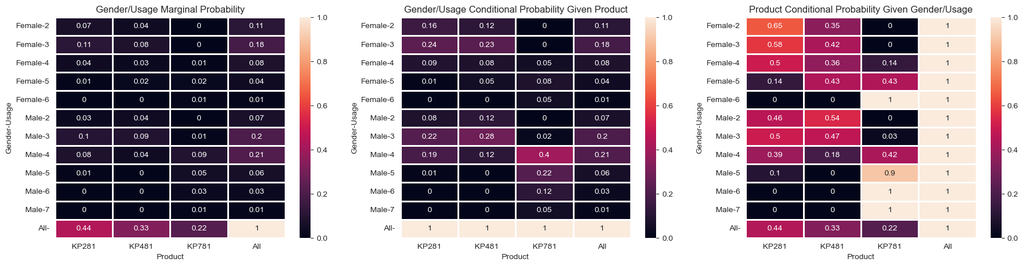

```python
gender_usage_prob = round(pd.crosstab(index=[df["Gender"],df["Usage"]],columns=df["Product"],margins=True,normalize=True),2)
product_prob_given_gender_usage = pd.crosstab(index=[df["Gender"],df["Usage"]],columns=df['Product'],margins=True).apply(lambda x: x/x.iloc[-1],axis=1).round(2)
gender_usage_prob_given_product = pd.crosstab(index=[df["Gender"],df["Usage"]],columns=df['Product'],margins=True).apply(lambda x: x/x.iloc[-1],axis=0).round(2)

fig,ax = plt.subplots(1,3,figsize=(22,5))

ax[0].set_title("Gender/Usage Marginal Probability")
sns.heatmap(gender_usage_prob, linewidth = 1, annot = True,ax= ax[0],vmin=0)

ax[1].set_title("Gender/Usage Conditional Probability Given Product")
sns.heatmap(gender_usage_prob_given_product, linewidth = 1, annot = True,ax= ax[1],vmin=0)

ax[2].set_title("Product Conditional Probability Given Gender/Usage")
sns.heatmap(product_prob_given_gender_usage, linewidth = 1, annot = True,ax= ax[2],vmin=0)


plt.show()
```

- Women with lower usage rates are more likely to choose KP281 as their preferred treadmill.
- Females who use the product more frequently are more inclined to purchase KP781.
- Males who rate their usage as 2 are predominantly the buyers of KP481.
- Males with higher usage rates are more likely to purchase KP781.

##### Gender Fitness

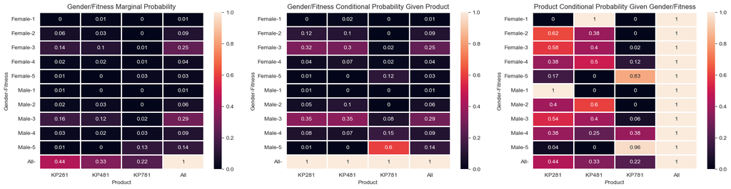

```python
gender_fitness_prob = round(pd.crosstab(index=[df["Gender"],df["Fitness"]],columns=df["Product"],margins=True,normalize=True),2)
product_prob_given_gender_fitness = pd.crosstab(index=[df["Gender"],df["Fitness"]],columns=df['Product'],margins=True).apply(lambda x: x/x.iloc[-1],axis=1).round(2)
gender_fitness_prob_given_product = pd.crosstab(index=[df["Gender"],df["Fitness"]],columns=df['Product'],margins=True).apply(lambda x: x/x.iloc[-1],axis=0).round(2)

fig,ax = plt.subplots(1,3,figsize=(22,5))

ax[0].set_title("Gender/Fitness Marginal Probability")
sns.heatmap(gender_fitness_prob, linewidth = 1, annot = True,ax= ax[0],vmin=0)

ax[1].set_title("Gender/Fitness Conditional Probability Given Product")
sns.heatmap(gender_fitness_prob_given_product, linewidth = 1, annot = True,ax= ax[1],vmin=0)

ax[2].set_title("Product Conditional Probability Given Gender/Fitness")
sns.heatmap(product_prob_given_gender_fitness, linewidth = 1, annot = True,ax= ax[2],vmin=0)


plt.show()
```

- KP281 treadmills are primarily favored by women with low fitness levels.
- Male buyers who rate themselves as 1 in fitness are most likely to purchase KP281.
- Customers who purchased KP781 treadmills tend to be the fittest males.

##### Gender Income

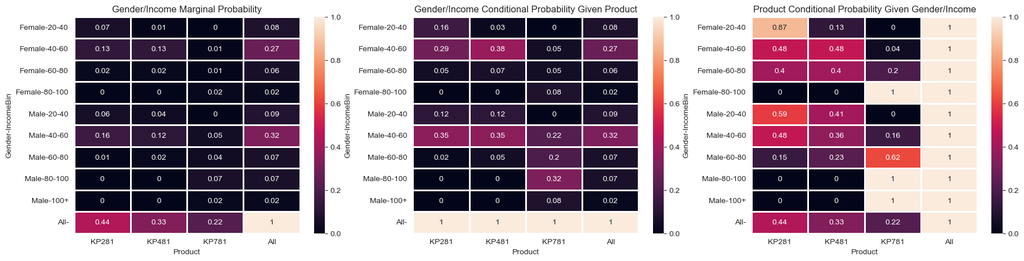

```python
gender_income_prob = round(pd.crosstab(index=[df["Gender"],df["IncomeBin"]],columns=df["Product"],margins=True,normalize=True),2)
product_prob_given_gender_income = pd.crosstab(index=[df["Gender"],df["IncomeBin"]],columns=df['Product'],margins=True).apply(lambda x: x/x.iloc[-1],axis=1).round(2)
gender_income_prob_given_product = pd.crosstab(index=[df["Gender"],df["IncomeBin"]],columns=df['Product'],margins=True).apply(lambda x: x/x.iloc[-1],axis=0).round(2)

fig,ax = plt.subplots(1,3,figsize=(22,5))

ax[0].set_title("Gender/Income Marginal Probability")
sns.heatmap(gender_income_prob, linewidth = 1, annot = True,ax= ax[0],vmin=0)

ax[1].set_title("Gender/Income Conditional Probability Given Product")
sns.heatmap(gender_income_prob_given_product, linewidth = 1, annot = True,ax= ax[1],vmin=0)

ax[2].set_title("Product Conditional Probability Given Gender/Income")
sns.heatmap(product_prob_given_gender_income, linewidth = 1, annot = True,ax= ax[2],vmin=0)


plt.show()
```

- Customers, both women and men, in the income band of 20-40 are most likely to choose KP281 treadmills.
- High-income earners, regardless of gender, are more inclined to purchase KP781.

##### Gender Miles

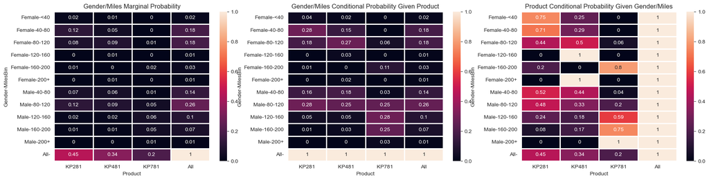

```python
gender_miles_prob = round(pd.crosstab(index=[df["Gender"],df["MilesBin"]],columns=df["Product"],margins=True,normalize=True),2)
product_prob_given_gender_miles = pd.crosstab(index=[df["Gender"],df["MilesBin"]],columns=df['Product'],margins=True).apply(lambda x: x/x.iloc[-1],axis=1).round(2)
gender_income_prob_given_miles = pd.crosstab(index=[df["Gender"],df["MilesBin"]],columns=df['Product'],margins=True).apply(lambda x: x/x.iloc[-1],axis=0).round(2)

fig,ax = plt.subplots(1,3,figsize=(22,5))

ax[0].set_title("Gender/Miles Marginal Probability")
sns.heatmap(gender_miles_prob, linewidth = 1, annot = True,ax= ax[0],vmin=0)

ax[1].set_title("Gender/Miles Conditional Probability Given Product")
sns.heatmap(gender_income_prob_given_miles, linewidth = 1, annot = True,ax= ax[1],vmin=0)

ax[2].set_title("Product Conditional Probability Given Gender/Miles")
sns.heatmap(product_prob_given_gender_miles, linewidth = 1, annot = True,ax= ax[2],vmin=0)


plt.show()
```

- Female buyers have the following purchase preferences:
  - Below 40 and 40-80 mile runners predominantly spend on KP281.
  - 120-160 and 200+ mile runners mostly spend on KP481.
  - 160-200 mile runners tend to spend on KP781.
- Male buyers who run between 40-120 miles are most likely to purchase KP281, whereas individuals running 160+ miles are more inclined to buy KP781.

##### Gender Marital

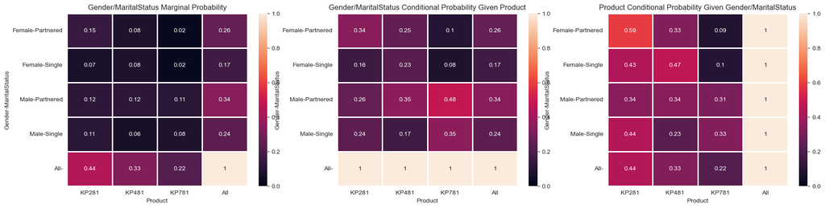

```python
gender_marital_prob = round(pd.crosstab(index=[df["Gender"],df["MaritalStatus"]],columns=df["Product"],margins=True,normalize=True),2)
product_prob_given_gender_marital = pd.crosstab(index=[df["Gender"],df["MaritalStatus"]],columns=df['Product'],margins=True).apply(lambda x: x/x.iloc[-1],axis=1).round(2)
gender_marital_prob_given_product = pd.crosstab(index=[df["Gender"],df["MaritalStatus"]],columns=df['Product'],margins=True).apply(lambda x: x/x.iloc[-1],axis=0).round(2)

fig,ax = plt.subplots(1,3,figsize=(22,5))

ax[0].set_title("Gender/MaritalStatus Marginal Probability")
sns.heatmap(gender_marital_prob, linewidth = 1, annot = True,ax= ax[0],vmin=0)

ax[1].set_title("Gender/MaritalStatus Conditional Probability Given Product")
sns.heatmap(gender_marital_prob_given_product, linewidth = 1, annot = True,ax= ax[1],vmin=0)

ax[2].set_title("Product Conditional Probability Given Gender/MaritalStatus")
sns.heatmap(product_prob_given_gender_marital, linewidth = 1, annot = True,ax= ax[2],vmin=0)


plt.show()
```

- Married females are the primary buyers of KP281 treadmills.
- Single females are more likely to purchase KP481 treadmills.
- Married males show no clear preference between KP281 and KP481.
- Single males are mostly likely to spend on KP281 treadmills.

## 4. Insights

### 4.1 Buisness Insights

Insights commented under each plot

### 4.3 Customer Profiling

Customer Profiling for Each Product:

KP281 Treadmills:

- Predominantly favored by women, especially those aged 40-50.
- Women with lower fitness levels and 12-16 years of education show a higher preference.
- Customers who rate their treadmill usage as 3, run below 40 miles per week, and have a lower income bracket (20-40) are more likely to purchase KP281.
- Target audience: Women in the age range of 40-50, with lower fitness levels, moderate education, and lower usage expectations.

Overall, KP281 targets women with lower fitness levels and usage expectations, KP481 appeals to individuals with moderate income and running goals, while KP781 targets high-income, educated, and fitness-oriented males with higher running expectations.